# Reparam PRS-Signature Associations (v1.1)

**Purpose.** Produce the supplement-style bar plot + FDR-significant heatmap + complete heatmap (as in Extended Data Fig 9 / Fig S27) using the non-centered (reparam) γ matrices from the 400K-pooled-warm-start pool. Includes the centered (published) pool alongside for direct comparison.

**Why.** The published Fig S27 used the centered MAP parameterization. Referee #2 / Nature v1.1 revision asked for a sensitivity check that the headline biology holds under the non-centered (reparam) parameterization. This notebook is that check, reproducible from the CSVs deposited in `docs/reparam/`.

**Two pools loaded (756 PRS-signature pairs each):**

| Pool | CSV | γ definition | FDR<0.05 cells |
| --- | --- | --- | --- |
| Centered (published) | `prs_signature_centered_gamma_associations.csv` | λ ~ GP(μ + Gγ, K), λ free | 116 |
| Reparam 400K-init | `prs_signature_400k_gamma_associations.csv` | λ = μ + Gγ + δ, δ ~ GP(0, K) | 416 |

Both CSVs were generated by `generate_prs_signature_plots.py` (Z = γ̄/SEM across 40 leave-one-out batches; Benjamini–Hochberg FDR across 756 pairs).

**Headline result.** The named biological hits (CAD→Sig5, T2D→Sig15, LDL→Sig5, BMI→Sig15, AF→Sig0, HT→Sig5) have the same sign and strong significance in both pools.

```python
import sys
from pathlib import Path

import matplotlib.pyplot as plt
import numpy as np
import pandas as pd
import seaborn as sns
from IPython.display import display
from matplotlib.patches import Patch

HERE = Path('.').resolve()
if HERE.name != 'reparam':
    # Notebook may be opened from repo root; resolve relative to known docs/reparam path.
    HERE = Path('/Users/sarahurbut/aladynoulli2/docs/reparam')

C = pd.read_csv(HERE / 'prs_signature_centered_gamma_associations.csv')
N = pd.read_csv(HERE / 'prs_signature_400k_gamma_associations.csv')

print(f'Centered (published) rows: {len(C)}, FDR<0.05: {C.significant_fdr.sum()}')
print(f'Reparam 400K-init    rows: {len(N)}, FDR<0.05: {N.significant_fdr.sum()}')

# Disease-category colours (same scheme as published Fig S27)
CATEGORY_COLORS = {
    'Cardiovascular': '#d62728',
    'Metabolic':      '#1f77b4',
    'Neurological':   '#2ca02c',
    'Cancer':         '#9467bd',
    'Autoimmune':     '#ff7f0e',
    'Other':          '#7f7f7f',
}
```

```
Centered (published) rows: 756, FDR<0.05: 116
Reparam 400K-init    rows: 756, FDR<0.05: 416
```

## Plot helpers (mirror `generate_prs_signature_plots.py`)

Three plots per pool: (1) top-30 PRS-signature pairs by |Z|, coloured by disease category; (2) FDR<0.05 heatmap; (3) complete 36×21 Z-score heatmap.

```python
def plot_top_bar(df, label, n_top=30):
    df = df.copy()
    df['absz'] = df['z_score'].abs()
    top = df.dropna(subset=['z_score']).nlargest(n_top, 'absz').sort_values('z_score')
    fig, ax = plt.subplots(figsize=(10, max(8, len(top) * 0.35)))
    colors = [CATEGORY_COLORS.get(c, CATEGORY_COLORS['Other']) for c in top['category']]
    ax.barh(range(len(top)), top['z_score'], color=colors, alpha=0.85)
    ax.set_yticks(range(len(top)))
    def make_label(r):
        s = f"{r['prs']} - {r['signature']}"
        if not np.isnan(r['p_value_fdr']):
            if r['p_value_fdr'] < 0.001:
                s += ' (FDR<0.001)'
            else:
                s += f" (FDR={r['p_value_fdr']:.3f})"
            if r['significant_fdr']:
                s += '*'
        return s
    ax.set_yticklabels(top.apply(make_label, axis=1), fontsize=9)
    ax.set_xlabel('Z-score (effect / SEM)', fontsize=12, fontweight='bold')
    ax.set_title(f'Top {n_top} PRS-Signature Associations -- {label}', fontsize=13, fontweight='bold', pad=10)
    ax.axvline(x=0, color='black', linestyle='--', linewidth=0.5, alpha=0.5)
    ax.grid(True, alpha=0.3, axis='x')
    handles = [Patch(facecolor=c, label=cat, alpha=0.85) for cat, c in CATEGORY_COLORS.items()]
    ax.legend(handles=handles, loc='lower right', fontsize=9, framealpha=0.95)
    plt.tight_layout()
    plt.show()


def plot_heatmap(df, label, fdr_only=False):
    sub = df[df['p_value_fdr'] < 0.05].copy() if fdr_only else df.copy()
    pivot = sub.pivot_table(values='z_score', index='prs', columns='signature', aggfunc='mean')
    # Order PRS by category then alphabetically
    cat_map = dict(zip(df['prs'].astype(str), df['category']))
    order = []
    for cat in ['Cardiovascular', 'Metabolic', 'Autoimmune', 'Neurological', 'Cancer', 'Other']:
        order.extend(sorted([p for p in pivot.index if cat_map.get(str(p)) == cat]))
    pivot = pivot.reindex([p for p in order if p in pivot.index])
    fig, ax = plt.subplots(figsize=(max(12, len(pivot.columns)*0.8), max(10, len(pivot)*0.4)))
    sns.heatmap(pivot, cmap='RdBu_r', center=0, vmin=-5, vmax=5,
                cbar_kws={'label': 'Z-score'}, ax=ax, linewidths=0.5, linecolor='gray')
    suffix = ' (FDR<0.05)' if fdr_only else ' (all 36 PRS x 21 signatures)'
    ax.set_title(f'PRS-Signature Z-scores -- {label}{suffix}', fontsize=13, fontweight='bold', pad=10)
    ax.set_xlabel('Signature', fontsize=12, fontweight='bold')
    ax.set_ylabel('Polygenic Risk Score', fontsize=12, fontweight='bold')
    plt.xticks(rotation=45, ha='right')
    plt.yticks(rotation=0)
    plt.tight_layout()
    plt.show()
```

## Centered (published) — three plots

These are equivalent to the published Fig S27 panels A, B, C, drawn directly from the deposited CSV.

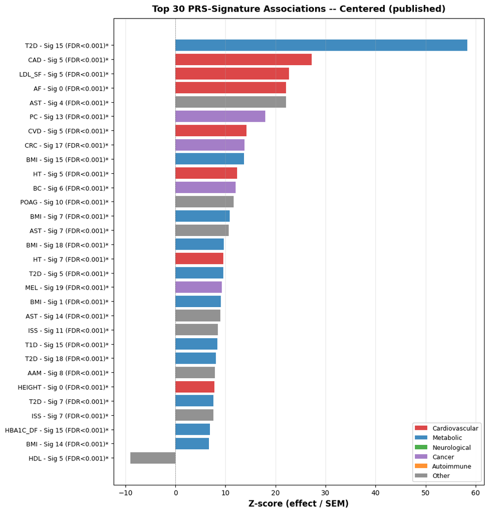

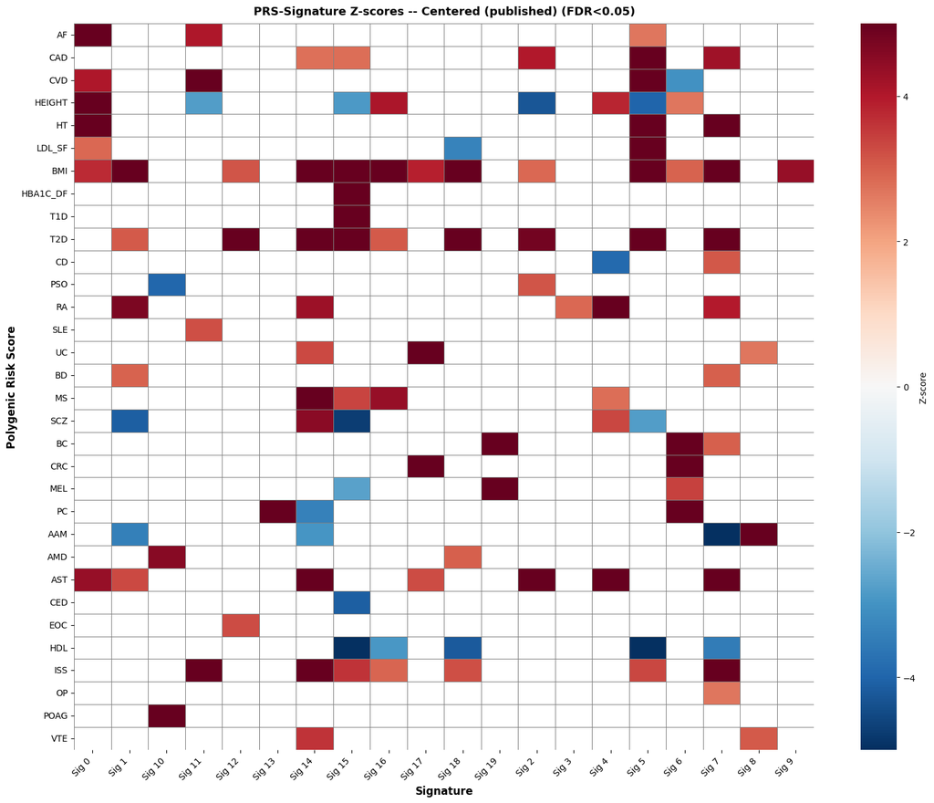

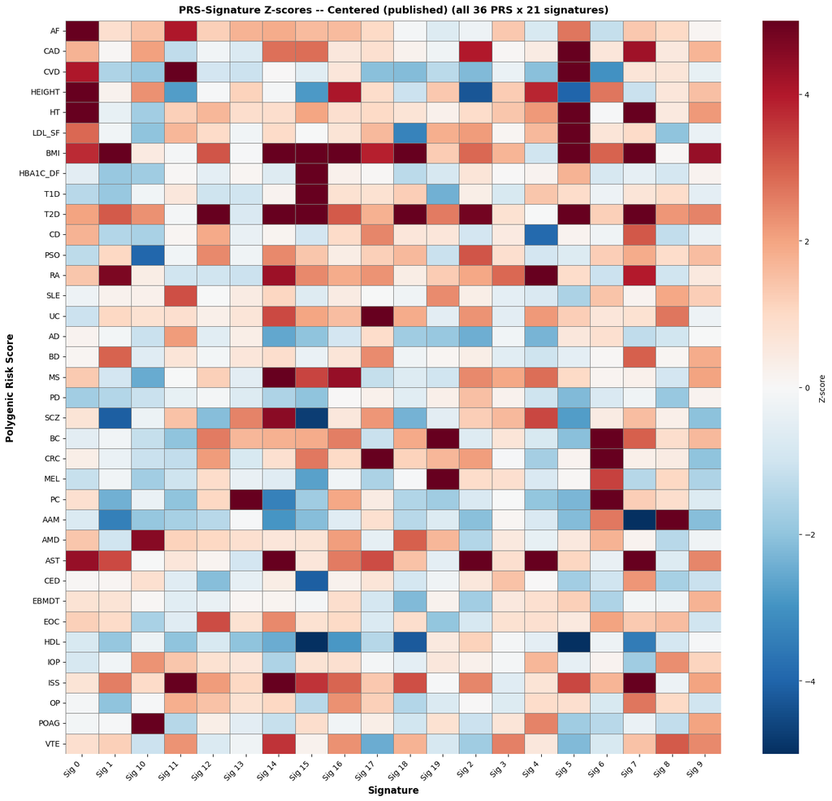

```python
plot_top_bar(C, 'Centered (published)')
plot_heatmap(C, 'Centered (published)', fdr_only=True)
plot_heatmap(C, 'Centered (published)', fdr_only=False)
```

## Reparam 400K-init (v1.1) — three plots

Same plot code applied to the reparam-400K γ matrix. Both pools are aggregated across 40 LOO batches; reparam pool warm-starts γ from a shared 400K-patient signature-score ridge regression.

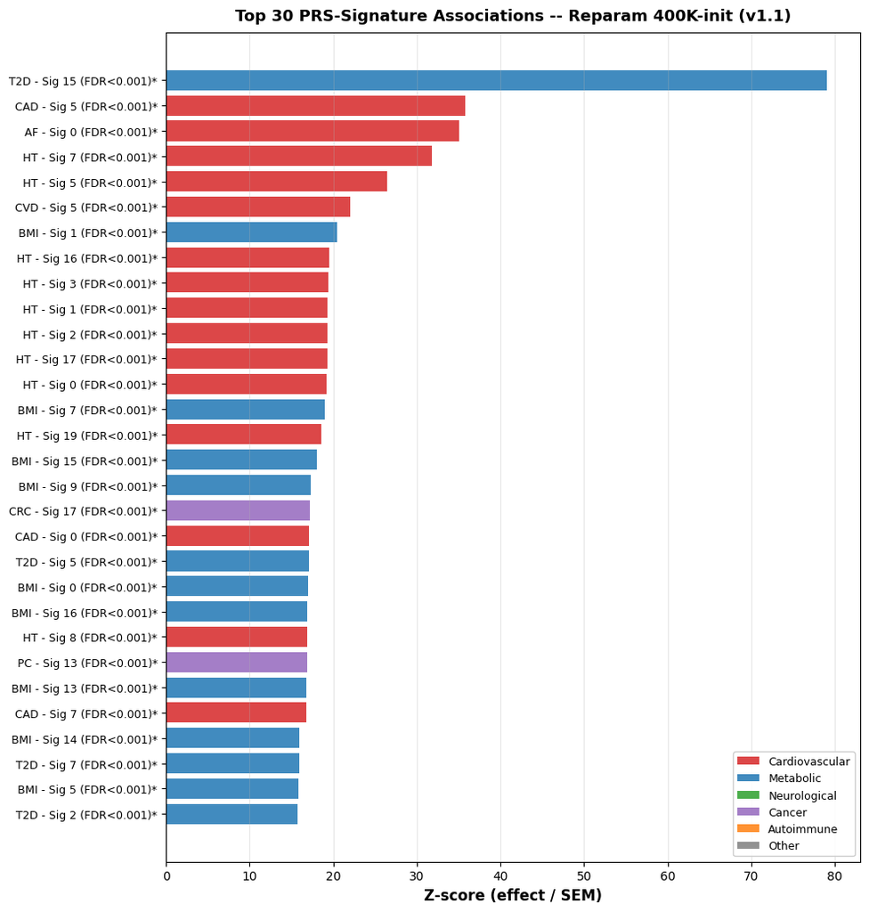

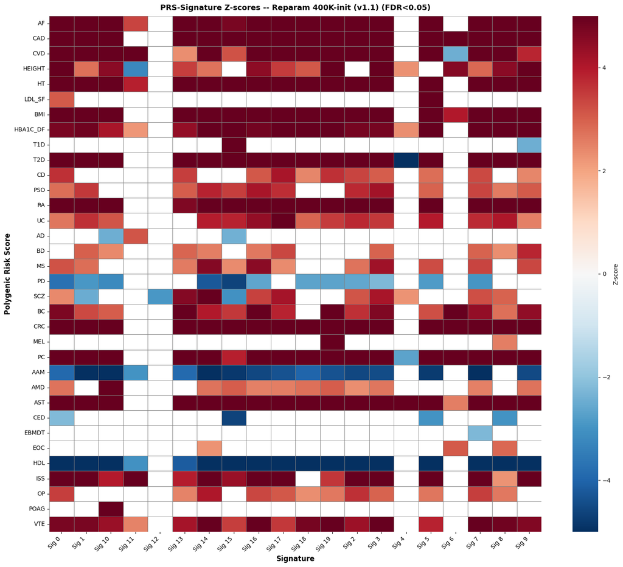

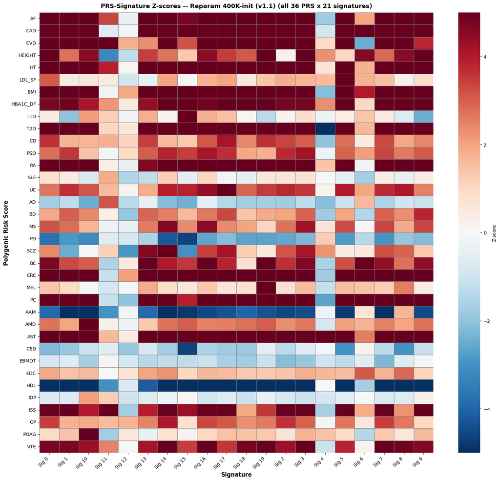

```python
plot_top_bar(N, 'Reparam 400K-init (v1.1)')
plot_heatmap(N, 'Reparam 400K-init (v1.1)', fdr_only=True)
plot_heatmap(N, 'Reparam 400K-init (v1.1)', fdr_only=False)
```

## Headline named hits — side-by-side

The biological hits the paper text highlights, in both pools.

```python
named = [('CAD', 'Sig 5'), ('LDL_SF', 'Sig 5'), ('T2D', 'Sig 15'),
         ('BMI', 'Sig 15'), ('AF', 'Sig 0'), ('HT', 'Sig 5'), ('CVD', 'Sig 5')]
m = (C.rename(columns=lambda c: c+'_c' if c not in ('prs','signature') else c)
     .merge(N.rename(columns=lambda c: c+'_n' if c not in ('prs','signature') else c),
            on=['prs','signature']))
rows = []
for p, s in named:
    r = m[(m['prs']==p) & (m['signature']==s)]
    if not len(r): continue
    r = r.iloc[0]
    rows.append({
        'PRS': p, 'Signature': s,
        'centered_gamma': f'{r.effect_c:+.4f}',  'centered_Z': f'{r.z_score_c:+.1f}',
        '400k_gamma':     f'{r.effect_n:+.4f}',  '400k_Z':     f'{r.z_score_n:+.1f}',
        'sign_agree': int(np.sign(r.effect_c) == np.sign(r.effect_n)),
    })
display(pd.DataFrame(rows))
```

|  | PRS | Signature | centered_gamma | centered_Z | 400k_gamma | 400k_Z | sign_agree |
| --- | --- | --- | --- | --- | --- | --- | --- |
| 0 | CAD | Sig 5 | +0.1534 | +27.2 | +0.3345 | +35.8 | 1 |
| 1 | LDL_SF | Sig 5 | +0.0713 | +22.7 | +0.1380 | +13.7 | 1 |
| 2 | T2D | Sig 15 | +0.1539 | +58.3 | +1.1458 | +79.1 | 1 |
| 3 | BMI | Sig 15 | +0.0220 | +13.7 | +0.2309 | +18.0 | 1 |
| 4 | AF | Sig 0 | +0.0379 | +22.1 | +0.3006 | +35.1 | 1 |
| 5 | HT | Sig 5 | +0.0475 | +12.3 | +0.2088 | +26.4 | 1 |
| 6 | CVD | Sig 5 | +0.0770 | +14.2 | +0.1687 | +22.0 | 1 |

## Z-score scatter (consistency check)

Correlation of the 756-cell Z map between the two pools, restricted to cells where both have a defined Z (Sig 20 is the reference and has no γ → 36 cells dropped).

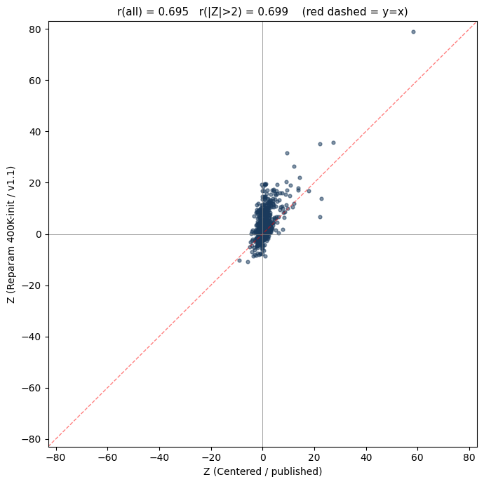

```python
mask = m.z_score_c.notna() & m.z_score_n.notna()
x = m.loc[mask, 'z_score_c'].values
y = m.loc[mask, 'z_score_n'].values
fig, ax = plt.subplots(figsize=(7, 7))
ax.scatter(x, y, s=12, alpha=0.55, c='#1a3a5c')
lim = max(np.abs(x).max(), np.abs(y).max()) * 1.05
ax.plot([-lim, lim], [-lim, lim], '--', color='red', alpha=0.5, lw=1)
ax.axhline(0, color='gray', lw=0.5); ax.axvline(0, color='gray', lw=0.5)
ax.set_xlabel('Z (Centered / published)')
ax.set_ylabel('Z (Reparam 400K-init / v1.1)')
r = np.corrcoef(x, y)[0, 1]
strong = (np.abs(x) > 2) | (np.abs(y) > 2)
r_s = np.corrcoef(x[strong], y[strong])[0, 1] if strong.sum() > 1 else np.nan
ax.set_title(f'r(all) = {r:.3f}   r(|Z|>2) = {r_s:.3f}    (red dashed = y=x)', fontsize=11)
ax.set_xlim(-lim, lim); ax.set_ylim(-lim, lim)
plt.tight_layout()
plt.show()
```

## Provenance

- **Centered γ source**: `paper_figs/fig4/gamma_adventures/prs_signatures_nolr/gamma_associations.csv` ≡ `SuppDataFiles-3/Annotation/gamma_associations.csv` (bit-for-bit). 40 LOO batches of UKB centered MAP fit; γ enters via GP prior mean of free λ.
- **Reparam 400K-init γ source**: 40 LOO batches at `Dropbox/censor_e_batchrun_vectorized_REPARAM_v3_nokappa_400k_init/`. Each batch warm-starts γ from `gamma_level_pooled_400k.pt` (signature-score ridge regression on 400K UKB participants). Trainer: `claudefile/train_nokappa_v3_all40_400k_init.py`.
- **Z / FDR computation**: `pyScripts/dec_6_revision/new_notebooks/main_paper_figures/generate_prs_signature_plots.py` (Z = γ̄ / SEM across 40 batches; BH-FDR across all 756 pairs).
- **CSVs in this folder**: `prs_signature_centered_gamma_associations.csv`, `prs_signature_400k_gamma_associations.csv`.
- **Comparison driver script**: `claudefile/compare_prs_signature_pools.py`.